# Plotting with Python Libraries

The follwing plots are examples of graphs that can be produced using various python libraries, namely Plotly and Seaborn. These libraries are dependent on other libraries, like matplotlib, numpy, and pandas.

In order to produce a local file to store this work, I have used a python notebook that has been exported to an html. This circumvents the need for python and python libraries to be installed in order to see the graphs.

### 3D Elevation Plot

The first graph covers the use of a elevation matrix, like a DEM, in a 3D plot. This plot has interactivity allowing the rotation of the dataframe and cross sectional value display on hover.

The raw code for this IPython notebook is by default hidden for easier reading. To toggle on/off the raw code, click here.

```python
from plotly import __version__
from plotly.offline import download_plotlyjs, init_notebook_mode, plot, iplot

print __version__ # requires version >= 1.9.0

init_notebook_mode(connected=True)
```

```
2.0.9
```

```python
import plotly.plotly as py
import plotly.graph_objs as go
import pandas as pd
df = pd.read_csv('https://raw.githubusercontent.com/plotly/datasets/master/volcano.csv')

data = [go.Surface(z=df.values.tolist(), colorscale='Viridis')]

layout = go.Layout(
    width=800,
    height=700,
    autosize=False,
    title='Volcano dataset',
    scene=dict(
        xaxis=dict(
            gridcolor='rgb(255, 255, 255)',
            zerolinecolor='rgb(255, 255, 255)',
            showbackground=True,
            backgroundcolor='rgb(230, 230,230)'
        ),
        yaxis=dict(
            gridcolor='rgb(255, 255, 255)',
            zerolinecolor='rgb(255, 255, 255)',
            showbackground=True,
            backgroundcolor='rgb(230, 230,230)'
        ),
        zaxis=dict(
            gridcolor='rgb(255, 255, 255)',
            zerolinecolor='rgb(255, 255, 255)',
            showbackground=True,
            backgroundcolor='rgb(230, 230,230)'
        ),
        aspectratio = dict( x=1, y=1, z=0.7 ),
        aspectmode = 'manual'
    )
)

fig = dict(data=data, layout=layout)

iplot(fig, filename='pandas-3d-surface')
```

[interactive chart not shown]

### Linear Regression Plots with 95% Confidence Interval

The following 3 plots show some basic linear regressions with their confidence intervals. The example data looks into the effects of advertising from 3 types of media on a certain product's sales.

First I displayed some general stats about the dataset and then I plotted their best lines of fit using Seaborn. Seaborn has a nice modern look that requires little coding, but has no interactivity.

```python
import pandas as pd

data = pd.read_csv('http://www-bcf.usc.edu/~gareth/ISL/Advertising.csv', index_col = 0)

print data.describe()
```

```
               TV       Radio   Newspaper       Sales
count  200.000000  200.000000  200.000000  200.000000
mean   147.042500   23.264000   30.554000   14.022500
std     85.854236   14.846809   21.778621    5.217457
min      0.700000    0.000000    0.300000    1.600000
25%     74.375000    9.975000   12.750000   10.375000
50%    149.750000   22.900000   25.750000   12.900000
75%    218.825000   36.525000   45.100000   17.400000
max    296.400000   49.600000  114.000000   27.000000
```

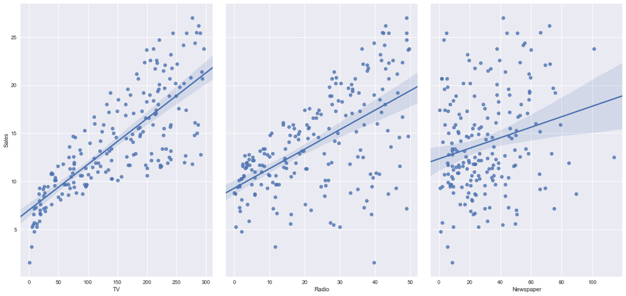

```python
import seaborn as sns

%matplotlib inline

sns.pairplot(data, x_vars=['TV', 'Radio', 'Newspaper'], y_vars= 'Sales', size = 8, aspect= 0.7, kind = 'reg')
```

Continuing the theme, I recreated these same plots in Plotly which gives the interactivity. The downside is lots more code to produce the same graph. It also has weird syntax since it is based of javascripts D3.js.

I was able to place annotations showing the exact value of the slope for the line of fit. This is really useful because it's difficult to tell what level of positive correlation each independent variable has.

```python
import plotly.plotly as py
import plotly.graph_objs as go

# Scientific libraries
from numpy import arange,array,ones
from scipy import stats

data = pd.read_csv('http://www-bcf.usc.edu/~gareth/ISL/Advertising.csv', index_col = 0)

y = data.Sales
x1 = data.TV
x2 = data.Radio
x3 = data.Newspaper

# Generated linear fit
slope, intercept, r_value, p_value, std_err = stats.linregress(x1,y)
line = slope*x1+intercept

# Creating the dataset, and generating the plot
trace1 = go.Scatter(
                  x=x1,
                  y=y,
                  mode='markers',
                  marker=go.Marker(color='rgb(255, 127, 14)'),
                  name='# of TV Ads'
                  )

trace2 = go.Scatter(
                  x=x1,
                  y=line,
                  mode='lines',
                  marker=go.Marker(color='rgb(31, 119, 180)'),
                  name='Fit'
                  )

annotation = go.Annotation(
                  x=50,
                  y=23.5,
                  text= 'Slope: ' + str(slope),
                  showarrow=False,
                  font=go.Font(size=16)
                  )
layout = go.Layout(
                title='Product sales from TV Ads',
                xaxis=dict(
                    title='Number of TV Ads',
                    titlefont=dict(
                    family='Courier New, monospace',
                    size=18,
                    color='#7f7f7f'
                    )
                ),
                yaxis=dict(
                    title='Sales',
                    titlefont=dict(
                    family='Courier New, monospace',
                    size=18,
                    color='#7f7f7f'
                    )
                ),
                plot_bgcolor='rgb(229, 229, 229)',
                annotations=[annotation]
                )

data = [trace1, trace2]
fig = go.Figure(data=data, layout=layout)

iplot(fig, filename='Linear-Fit-in-python')

# Generated linear fit
slope, intercept, r_value, p_value, std_err = stats.linregress(x2,y)
line = slope*x2+intercept

# Creating the dataset, and generating the plot
trace1 = go.Scatter(
                  x=x2,
                  y=y,
                  mode='markers',
                  marker=go.Marker(color='rgb(255, 127, 14)'),
                  name='# of Radio Ads'
                  )

trace2 = go.Scatter(
                  x=x2,
                  y=line,
                  mode='lines',
                  marker=go.Marker(color='rgb(31, 119, 180)'),
                  name='Fit'
                  )

annotation = go.Annotation(
                  x=10,
                  y=23,
                  text= 'Slope: ' + str(slope),
                  showarrow=False,
                  font=go.Font(size=16)
                  )
layout = go.Layout(
                title='Product sales from Radio Ads',
                xaxis=dict(
                    title='Number of Radio Ads',
                    titlefont=dict(
                    family='Courier New, monospace',
                    size=18,
                    color='#7f7f7f'
                    )
                ),
                yaxis=dict(
                    title='Sales',
                    titlefont=dict(
                    family='Courier New, monospace',
                    size=18,
                    color='#7f7f7f'
                    )
                ),
                plot_bgcolor='rgb(229, 229, 229)',
                annotations=[annotation]
                )

data = [trace1, trace2]
fig = go.Figure(data=data, layout=layout)

iplot(fig, filename='Linear-Fit-in-python')

# Generated linear fit
slope, intercept, r_value, p_value, std_err = stats.linregress(x3,y)
line = slope*x3+intercept

# Creating the dataset, and generating the plot
trace1 = go.Scatter(
                  x=x3,
                  y=y,
                  mode='markers',
                  marker=go.Marker(color='rgb(255, 127, 14)'),
                  name='# of Newspaper Ads'
                  )

trace2 = go.Scatter(
                  x=x3,
                  y=line,
                  mode='lines',
                  marker=go.Marker(color='rgb(31, 119, 180)'),
                  name='Fit'
                  )

annotation = go.Annotation(
                  x=100.9,
                  y=17.8,
                  text= 'Slope: ' + str(slope),
                  showarrow=True,
                  font=go.Font(size=16)
                  )
layout = go.Layout(
                title='Product sales from Newspaper Ads',
                xaxis=dict(
                    title='Number of Newspaper Ads',
                    titlefont=dict(
                    family='Courier New, monospace',
                    size=18,
                    color='#7f7f7f'
                    )
                ),
                yaxis=dict(
                    title='Sales',
                    titlefont=dict(
                    family='Courier New, monospace',
                    size=18,
                    color='#7f7f7f'
                    )
                ),
                plot_bgcolor='rgb(229, 229, 229)',
                annotations=[annotation]
                )

data = [trace1, trace2]
fig = go.Figure(data=data, layout=layout)

iplot(fig, filename='Linear-Fit-in-python')
```

[interactive chart not shown]

*...looking to continue with logistic regressions and cross validations*